# Splitting Hairs

```r
library(readr)
library(ggplot2)
library(dplyr)
library(readxl)
library(lme4)
library(tidyverse)
library(nlme)
library(stringi)
library(scales)

# For PCA
library(ggfortify)
library("FactoMineR")
library("factoextra")
library(cluster)
library(lfda)
library(ggpubr)

# For LDA
library(caret)
library(MASS)
```

Importing and editing data to make R happy

```r
#morphData <- read_excel("SplittingHairsMorphology.xlsx")
#
# # Means of grouped variables
#MinPL <- stri_split_fixed(morphData$Minor.plate.length.mm, ',', simplify=T)
#MinPL <- `dim<-`(as.numeric(MinPL), dim(MinPL))
#morphData$MinPlateLenMean <-rowMeans(MinPL, na.rm=T)
#
# ### Do this for all grouped variables ###
#
# # These thicknesses are different because we need them individually to calculate cross sectional area for bending stiffness
#MajPTlab <- stri_split_fixed(morphData$Major.plate.thickness.labial.mm.g2f, ',', simplify=T)
#MajPTlab <- as.data.frame(`dim<-`(as.numeric(MajPTlab), dim(MajPTlab)))
#MajPTlab <- MajPTlab %>%
##         rename("MajPTlab.gum" = "V1", "MajPTlab.mid"="V2", "MajPTlab.fringe"="V3")
#
#MajPTling <- stri_split_fixed(morphData$Major.plate.thickness.lingual.mm.g2f, ',', simplify=T)
#MajPTling <- as.data.frame(`dim<-`(as.numeric(MajPTling), dim(MajPTling)))
#MajPTling <- MajPTling %>%
##         rename("MajPTling.gum" = "V1", "MajPTling.mid"="V2", "MajPTling.fringe"="V3")

#### maybe easier to create a dataframe of just the data we want to do analysis on (ie without the notes or columns with commas and all that)
```

## Ferris’ Code

This chunk takes the columns where there are multiple measurements per plate (seperated by commas) and seperates them out. It takes the mean of the individual values and adds them back in.

```r
morphData <- read_excel("SplittingHairsMorphology.xlsx")
# Means of grouped variables - do for every variable with deliberate commas.
# For Minor Plate Length
MinPL <- stri_split_fixed(morphData$Minor.plate.length.mm, ',', simplify=T)
MinPL <- `dim<-`(as.numeric(MinPL), dim(MinPL))
morphData$MinPlateLenMean <-rowMeans(MinPL, na.rm=T)

# For Minor Plate Width
MinPlWi <- stri_split_fixed(morphData$Minor.plate.width, ',', simplify=T)
MinPlWi <- `dim<-`(as.numeric(MinPlWi), dim(MinPlWi))
morphData$MinWidMean <-rowMeans(MinPlWi, na.rm=T)

# For Major Plate Fringe Diameters
MajPlDiam <- stri_split_fixed(morphData$Major.plate.fringe.diameters.mm.g2f, ',', simplify=T)
MajPlDiam <- `dim<-`(as.numeric(MajPlDiam), dim(MajPlDiam))
morphData$MajPlDiamMean <-rowMeans(MajPlDiam, na.rm=T)

# For Minor Plate Fringe Diameters
MinPlDiam <- stri_split_fixed(morphData$Minor.plate.fringe.diameter.mm.l2l, ',', simplify=T)
MinPlDiam <- `dim<-`(as.numeric(MinPlDiam), dim(MinPlDiam))
morphData$MinPlDiamMean <-rowMeans(MinPlDiam, na.rm=T)

# For Minor Plate Lingual Thicknesses
MinPlThick <- stri_split_fixed(morphData$Minor.plate.thickness.lingual.mm, ',', simplify=T)
MinPlThick <- `dim<-`(as.numeric(MinPlThick), dim(MinPlThick))
morphData$MinPlThickMean <-rowMeans(MinPlThick, na.rm=T)

# Rack Spacing (Majors)
MajRacSpac <- stri_split_fixed(morphData$ant2pos.Rack.major.plate.spacing.mm, ',', simplify=T)
MajRacSpac <- `dim<-`(as.numeric(MajRacSpac), dim(MajRacSpac))
morphData$MajRacSpackMean <-rowMeans(MajRacSpac, na.rm=T)

# Rack Spacing (Minors)
MinRacSpac <- stri_split_fixed(morphData$ant2pos.Rack.minor.plate.spacing.mm, ',', simplify=T)
MinRacSpac <- `dim<-`(as.numeric(MinRacSpac), dim(MinRacSpac))
morphData$MinRacSpackMean <-rowMeans(MinRacSpac, na.rm=T)

# These thicknesses are different because we need them individually to calculate cross sectional area for bending stiffness. So I do the same thing where I add them back into the morph datasheet as means, but I also exported the CSV and merged them in to calculate cross sectional area. WriteCSV is commented out because it's done already so no need to do it again.

MajPTlab <- stri_split_fixed(morphData$Major.plate.thickness.labial.mm.g2f, ',', simplify=T)
MajPTlab <- as.data.frame(`dim<-`(as.numeric(MajPTlab), dim(MajPTlab)))
morphData$MajPTlabMean <-rowMeans(MajPTlab, na.rm=T)
MajPTlab.b1 <- MajPTlab %>%
  rename("MajPTlab.gum" = "V1", "MajPTlab.mid"="V2", "MajPTlab.fringe"="V3")
MajPTlab.b1 = cbind(MajPTlab.b1, morphData[,c(1:2)])
#write.csv(MajPTlab.b1, "MajPTlab.b1.csv", row.names=FALSE)

MajPTling <- stri_split_fixed(morphData$Major.plate.thickness.lingual.mm.g2f, ',', simplify=T)
MajPTling <- as.data.frame(`dim<-`(as.numeric(MajPTling), dim(MajPTling)))
morphData$MajPTlingMean <-rowMeans(MajPTling, na.rm=T)
MajPTling.b2 <- MajPTling %>%
  rename("MajPTling.gum" = "V1", "MajPTling.mid"="V2", "MajPTling.fringe"="V3")
MajPTling.b2 = cbind(MajPTling.b2, morphData[,c(1:2)])
#write.csv(MajPTling.b2, "MajPTling.b2.csv", row.names=FALSE)

# For Major Plate Width
MajPlWi <- stri_split_fixed(morphData$Major.plate.width.g2f, ',', simplify=T)
MajPlWi <- as.data.frame(`dim<-`(as.numeric(MajPlWi), dim(MajPlWi)))
morphData$MajPlWiMean <-rowMeans(MajPlWi, na.rm=T)
MajPlWi.h <- MajPlWi %>%
  rename("MajPlWi.gum" = "V1", "MajPlWi.mid"="V2", "MajPlWi.fringe"="V3")
MajPlWi.h = cbind(MajPlWi.h, morphData[,c(1:2)])
#write.csv(MajPlWi.h, "MajPlWi.h.csv", row.names=FALSE)

morphData$Estimated.Age.Class <- factor(morphData$Estimated.Age.Class , levels=c("Calf", "Subadult", "Adult"))
```

## This chunk imports the MTS data and calculates bendign stiffness and youngs modulus

```r
#Bending Mechanics
MTSmergeRaw<- read_excel("MTSMerge.xlsx")

# Arrange in order for plotting
MTSmergeRaw$bendLocation <- factor(MTSmergeRaw$bendLocation , levels=c("gum", "mid", "fringe"))
MTSmergeRaw$Age <- factor(MTSmergeRaw$Age , levels=c("Calf", "Subadult", "Adult"))

#Kinematics + Mechanics
# Mechanics <- merge(PoacherKinematics, MTSmerge,by="indiv")

secondMoment <- read_excel("SecondMomentSheet.xlsx")

MTSmerge <- merge(MTSmergeRaw, secondMoment, by=c("fieldID","Plate"))

MTSmerge$I <- (MTSmerge$h/1000 * ((MTSmerge$b1/1000+MTSmerge$b2/1000)/2)^3)/48

MTSmerge$E.Pa <- (MTSmerge$loadAtDeltaSlope * (MTSmerge$length/1000)^3) /
  (MTSmerge$ExtensionAtDeltaSlope/1000 * 48 * MTSmerge$I)

MTSmerge$E.Gpa <- MTSmerge$E.Pa/1000000000

MTSmerge$EI <- MTSmerge$E.Pa*MTSmerge$I

MTSmerge$Stress <- MTSmerge$loadAtHoldStart/(MTSmerge$h/1000 * (MTSmerge$b1/1000+MTSmerge$b2/1000)/2)/2

MTSmerge$Stress.MPa <- MTSmerge$Stress/1000000
```

##Mechanics Stats These are simple linear models to see if there is a difference in material testing data based on Sex, Age, or Standard length. Right now just testing one thing, but feel free to look at the stats for Youngs Modulus, Flexural Stiffness, Stress, etc!

```r
TukeyHSD(mechModel02.av)
```

```
  Tukey multiple comparisons of means
    95% family-wise confidence level

Fit: aov(formula = mechModel02)

$bendLocation
                   diff         lwr          upr     p adj
mid-gum    -0.008688166 -0.02687231  0.009495976 0.5000351
fringe-gum -0.075670025 -0.09385417 -0.057485883 0.0000000
fringe-mid -0.066981859 -0.08516600 -0.048797718 0.0000000

$Age
                     diff           lwr        upr     p adj
Subadult-Calf  0.02465435 -0.0000911308 0.04939983 0.0510949
Adult-Calf     0.11083035  0.0870556584 0.13460504 0.0000000
Adult-Subadult 0.08617600  0.0700804560 0.10227154 0.0000000
```

##Mechanics Figure Examples

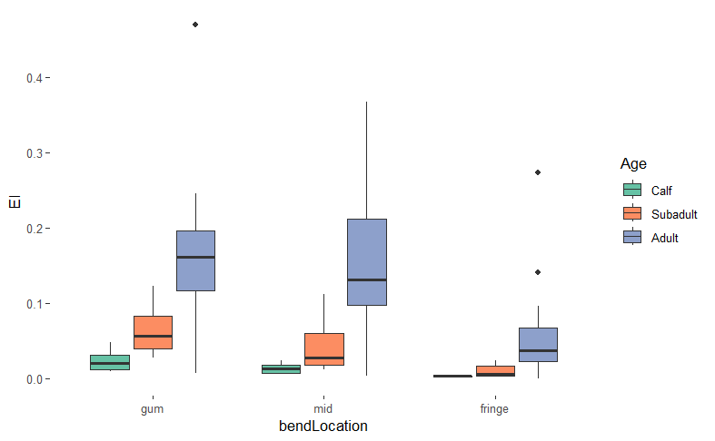

#Scaling Mechanics Figures

```r
MTSmerge.fringe <- filter(MTSmerge, bendLocation == "fringe")
MTSmerge.mid <- filter(MTSmerge, bendLocation == "mid")
MTSmerge.gum <- filter(MTSmerge, bendLocation == "gum")

FLMin = min(log(MTSmerge$StandardLength), na.rm = TRUE)
minIndex = which.min(log(MTSmerge$StandardLength))

ggplot(data = MTSmerge, aes(x = log(StandardLength), y = log(FS), color = bendLocation), outlier.shape=NA)+
  geom_point(size = 2)+
  geom_abline(intercept = -25.75, slope = 3, size=1, linetype="dashed")+
  geom_abline(intercept = -24.1, slope = 3, size=1, linetype="dashed")+
  geom_abline(intercept = -23.3, slope = 3, size=1, linetype="dashed")+
  geom_smooth(method = "lm", se = FALSE, size=1)+
  theme_minimal()+
  theme(text = element_text(size = 25))+
  ylab("log Major Plate Length (cm)")+
  xlab("log Whale Length (cm)")+
  scale_colour_brewer(palette = "Dark2")+
  scale_y_continuous(name = "Flexural Stiffness (EI)", labels = math_format(10^.x))+
  scale_x_continuous(name = "Standard.Length (cm)", labels = math_format(10^.x))
ggsave("scaledEIvSL.png")
#log(MTSmerge$FS[minIndex])-FLMin
```

[output not shown]

# This section is for taking the mean and SD of morphData’s numerical columns.

```r
summary(morphData)

femMorphData <- morphData %>%
  filter(morphData$Sex == 'Female')
summary(femMorphData)

malMorphData <- morphData %>%
  filter(morphData$Sex == 'Male')
summary(malMorphData)

aduMorphData <- morphData %>%
  filter(morphData$Estimated.Age.Class == 'Adult')
summary(aduMorphData)

juvMorphData <- morphData %>%
  filter(!morphData$Estimated.Age.Class == 'Adult')
summary(juvMorphData)
```

#This section is for MANOVA summaries of the morphometric data.

```r
summary.aov(ageMANOVA)
```

```
 Response Standard.Length.cm :
                    Df  Sum Sq Mean Sq F value    Pr(>F)
Estimated.Age.Class  2 1945221  972610  188.75 < 2.2e-16 ***
Residuals           50  257638    5153
---
Signif. codes:  0 ‘***’ 0.001 ‘**’ 0.01 ‘*’ 0.05 ‘.’ 0.1 ‘ ’ 1

 Response Major.plate.length.mm :
                    Df Sum Sq Mean Sq F value  Pr(>F)
Estimated.Age.Class  2  39204 19602.0  6.6681 0.00271 **
Residuals           50 146984  2939.7
---
Signif. codes:  0 ‘***’ 0.001 ‘**’ 0.01 ‘*’ 0.05 ‘.’ 0.1 ‘ ’ 1

 Response Fringe.density.at.midpoint.per.1cm :
                    Df Sum Sq Mean Sq F value Pr(>F)
Estimated.Age.Class  2   1.44  0.7178  0.1003 0.9047
Residuals           50 357.77  7.1554

 Response MajPlDiamMean :
                    Df Sum Sq Mean Sq F value    Pr(>F)
Estimated.Age.Class  2 1.1193 0.55964   17.75 1.497e-06 ***
Residuals           50 1.5765 0.03153
---
Signif. codes:  0 ‘***’ 0.001 ‘**’ 0.01 ‘*’ 0.05 ‘.’ 0.1 ‘ ’ 1

 Response MajPTlabMean :
                    Df Sum Sq Mean Sq F value    Pr(>F)
Estimated.Age.Class  2 73.099  36.550  27.195 1.018e-08 ***
Residuals           50 67.199   1.344
---
Signif. codes:  0 ‘***’ 0.001 ‘**’ 0.01 ‘*’ 0.05 ‘.’ 0.1 ‘ ’ 1

 Response MajPTlingMean :
                    Df Sum Sq Mean Sq F value    Pr(>F)
Estimated.Age.Class  2 64.489  32.244  27.878 7.355e-09 ***
Residuals           50 57.831   1.157
---
Signif. codes:  0 ‘***’ 0.001 ‘**’ 0.01 ‘*’ 0.05 ‘.’ 0.1 ‘ ’ 1

 Response MajPlWiMean :
                    Df Sum Sq Mean Sq F value    Pr(>F)
Estimated.Age.Class  2 2729.3 1364.64  17.505 1.728e-06 ***
Residuals           50 3897.9   77.96
---
Signif. codes:  0 ‘***’ 0.001 ‘**’ 0.01 ‘*’ 0.05 ‘.’ 0.1 ‘ ’ 1
```

```r
FLMin = min(log(morphData$Standard.Length.cm), na.rm = TRUE)
minIndex = which.min(morphData$Standard.Length.cm)

ggplot(data = morphData, aes(x = log(Standard.Length.cm), y = log(Major.plate.length.mm/10)))+
  geom_point(size = 3)+
  geom_abline(intercept = log(morphData$Major.plate.length.mm[minIndex]/10)-FLMin,
              slope = 1, size=2, linetype="dashed")+
  geom_smooth(method = "lm", se = FALSE, size=2)+
  theme_classic()+
  theme(text = element_text(size = 25))+
  ylab("log Major Plate Length (cm)")+
  xlab("log Whale Length (cm)")+
  scale_y_continuous(name = "Major Plate Length (mm)", labels = math_format(10^.x))+
  scale_x_continuous(name = "Standard.Length (cm)", labels = math_format(10^.x))

## Plot I modeled this from
# ggplot(data = CSDat, aes(x = log(FishLength.mm), y = log(SpineLength.Bone)))+
#   geom_point(aes(color = Position), size = 2)+
#   geom_abline(intercept = log(CSDat$SpineLength.Bone[minIndex])-FLMin,
#               slope = 1,size=2, linetype="dashed")+
#   geom_smooth(method = "lm", se = FALSE, size=2)+
#   theme_classic()+
# #  theme(text = element_text(size = 25))+
#   ylab("log Spine Length.Bone (mm)")+
#   xlab("log Fish Length (mm)")+
#   scale_color_manual(values = posColors)
# #  scale_color_brewer(palette = "YlOrRd")
```

[output not shown]

#Scailing Stats - Fringe This is where you can get the slope for the lines

```r
MTSmerge.fringe <- filter(MTSmerge, bendLocation == "fringe")
ampRMA <- lm(formula = log(loadAtDeltaSlope) ~ log(StandardLength), data = MTSmerge.fringe)
coef(ampRMA)

strideRMA <- lm(formula = log(maxLoad) ~ log(StandardLength), data = MTSmerge.fringe)
coef(strideRMA)

freqRMA <- lm(formula = log(totalWork) ~ log(StandardLength), data = MTSmerge.fringe)
coef(freqRMA)

FSRMA <- lm(formula = log(FS) ~ log(StandardLength), data = MTSmerge.fringe)
coef(FSRMA)
```

#Scailing Stats - mid

```r
MTSmerge.mid <- filter(MTSmerge, bendLocation == "mid")
ampRMA <- lm(formula = log(loadAtDeltaSlope) ~ log(StandardLength), data = MTSmerge.mid)
coef(ampRMA)

strideRMA <- lm(formula = log(maxLoad) ~ log(StandardLength), data = MTSmerge.mid)
coef(strideRMA)

freqRMA <- lm(formula = log(totalWork) ~ log(StandardLength), data = MTSmerge.mid)
coef(freqRMA)

FSRMA <- lm(formula = log(FS) ~ log(StandardLength), data = MTSmerge.mid)
coef(FSRMA)
```

#Scailing Stats - gum

```r
MTSmerge.gum <- filter(MTSmerge, bendLocation == "gum")
ampRMA <- lm(formula = log(loadAtDeltaSlope) ~ log(StandardLength), data = MTSmerge.gum)
coef(ampRMA)

strideRMA <- lm(formula = log(maxLoad) ~ log(StandardLength), data = MTSmerge.gum)
coef(strideRMA)

freqRMA <- lm(formula = log(totalWork) ~ log(StandardLength), data = MTSmerge.gum)
coef(freqRMA)

FSRMA <- lm(formula = log(FS) ~ log(StandardLength), data = MTSmerge.gum)
coef(FSRMA)
```